# Data Wrangling and Analysis, Spring 2022, University of Helsinki Homework report

3/3/2022

# Description on the study

## General information on the data

Data was downloaded from: https://www.europeansocialsurvey.org/download.html?file=ESS9e03_1&y=2018.  
Codebook fro the data can be found by the following link: chrome-extension://efaidnbmnnnibpcajpcglclefindmkaj/viewer.html?pdfurl=https%3A%2F%2Fwww.europeansocialsurvey.org%2Fdocs%2Fround9%2Fsurvey%2FESS9_appendix_a7_e03_1.pdf&clen=2111156.

The European Social Survey (ESS) is an academically-driven multi-country survey, which has been administered in over 35 countries to date. Its three aims are, firstly – to monitor and interpret changing public attitudes and values within Europe and to investigate how they interact with Europe’s changing institutions, secondly – to advance and consolidate improved methods of cross-national survey measurement in Europe and beyond, and thirdly – to develop a series of European social indicators, including attitudinal indicators. For the course we will use round 9 ESS.

# Import and restrict data

```r
# set working directory
setwd("C:/R scripts/DWA2022")

#import data
library(haven) # to open csv
data <- read_sav("C:/R scripts/DWA2022/ESS9e03_1.sav")
head(data)
```

| name | essround | edition | proddate | idno | cntry | nwspol | netusoft | netustm | ppltrst | pplfair | pplhlp | polintr | psppsgva | actrolga | psppipla | cptppola | trstprl | trstlgl | trstplc | trstplt | trstprt | trstep | trstun | vote | prtvtcat | prtvtdbe | prtvtdbg | prtvtgch | prtvtbcy | … |
| --- | --- | --- | --- | --- | --- | --- | --- | --- | --- | --- | --- | --- | --- | --- | --- | --- | --- | --- | --- | --- | --- | --- | --- | --- | --- | --- | --- | --- | --- | --- |
| ESS9e03_1 | 9 | 3.1 | 17.02.2021 | 27 | AT | 60 | 5 | 180 | 2 | 2 | 2 | 3 | 3 | 2 | 2 | 2 | 5 | 10 | 10 | 5 | 5 | 5 | 5 | 1 | 3 | NA | NA | NA | NA | … |
| ESS9e03_1 | 9 | 3.1 | 17.02.2021 | 137 | AT | 10 | 5 | 20 | 7 | 8 | 7 | 2 | 3 | 2 | 3 | 2 | 7 | 8 | 8 | 3 | 4 | 5 | 2 | 1 | 1 | NA | NA | NA | NA | … |
| ESS9e03_1 | 9 | 3.1 | 17.02.2021 | 194 | AT | 60 | 4 | 180 | 5 | 7 | 7 | 4 | 2 | 1 | 3 | 2 | 6 | 8 | 8 | 5 | 5 | 5 | 5 | 1 | 2 | NA | NA | NA | NA | … |
| ESS9e03_1 | 9 | 3.1 | 17.02.2021 | 208 | AT | 45 | 5 | 120 | 3 | 9 | 5 | 3 | 2 | 2 | 3 | 1 | 0 | 5 | 8 | 3 | 3 | 0 | 2 | 1 | 2 | NA | NA | NA | NA | … |
| ESS9e03_1 | 9 | 3.1 | 17.02.2021 | 220 | AT | 30 | 1 | NA | 5 | 8 | 4 | 2 | 1 | 1 | 1 | 3 | 7 | 8 | 8 | 7 | 7 | 5 | 5 | 1 | 2 | NA | NA | NA | NA | … |
| ESS9e03_1 | 9 | 3.1 | 17.02.2021 | 254 | AT | 45 | 2 | NA | 8 | 7 | 6 | 2 | 2 | 2 | 3 | 2 | 6 | 5 | 7 | 5 | 5 | 4 | 6 | 1 | 1 | NA | NA | NA | NA | … |

```r
dim(data) #everything is right
```

```
## [1] 49519   572
```

```r
# create a sum var, wxluding missing values
library(tidyverse)
library(dplyr)

#create mean var
data$img_avg <- rowMeans(select(data, imwbcnt, imbgeco, imueclt), na.rm = TRUE)
head(data$img_avg)
```

```
## [1] 3.666667 4.666667 5.666667 5.000000 4.333333 6.000000
```

```r
# select Finnish and Italian data
cntry_target <- c("EE", "LT", "LV")
data7 <- data %>% filter(cntry %in% cntry_target) %>%
  select(., cntry, agea, gndr, img_avg, polintr, stflife)
data7 <- data7[complete.cases(data7[ ,c("cntry", "agea", "gndr", "img_avg", "polintr", "stflife")]), ]
summary(data7)
```

```
##     cntry                agea            gndr          img_avg
##  Length:4574        Min.   :15.00   Min.   :1.000   Min.   : 0.000
##  Class :character   1st Qu.:39.00   1st Qu.:1.000   1st Qu.: 3.667
##  Mode  :character   Median :56.00   Median :2.000   Median : 5.000
##                     Mean   :53.77   Mean   :1.633   Mean   : 5.019
##                     3rd Qu.:68.00   3rd Qu.:2.000   3rd Qu.: 6.333
##                     Max.   :90.00   Max.   :2.000   Max.   :10.000
##     polintr         stflife
##  Min.   :1.000   Min.   : 0.000
##  1st Qu.:2.000   1st Qu.: 5.000
##  Median :3.000   Median : 7.000
##  Mean   :2.763   Mean   : 6.629
##  3rd Qu.:3.000   3rd Qu.: 8.000
##  Max.   :4.000   Max.   :10.000
```

```r
head(data7)
```

| cntry | agea | gndr | img_avg | polintr | stflife |
| --- | --- | --- | --- | --- | --- |
| EE | 37 | 2 | 2.666667 | 3 | 10 |
| EE | 72 | 1 | 5.000000 | 1 | 9 |
| EE | 57 | 1 | 3.000000 | 1 | 5 |
| EE | 56 | 2 | 4.000000 | 4 | 5 |
| EE | 53 | 2 | 6.666667 | 4 | 4 |
| EE | 35 | 1 | 6.666667 | 2 | 5 |

```r
dim(data7) #looks right!
```

```
## [1] 4574    6
```

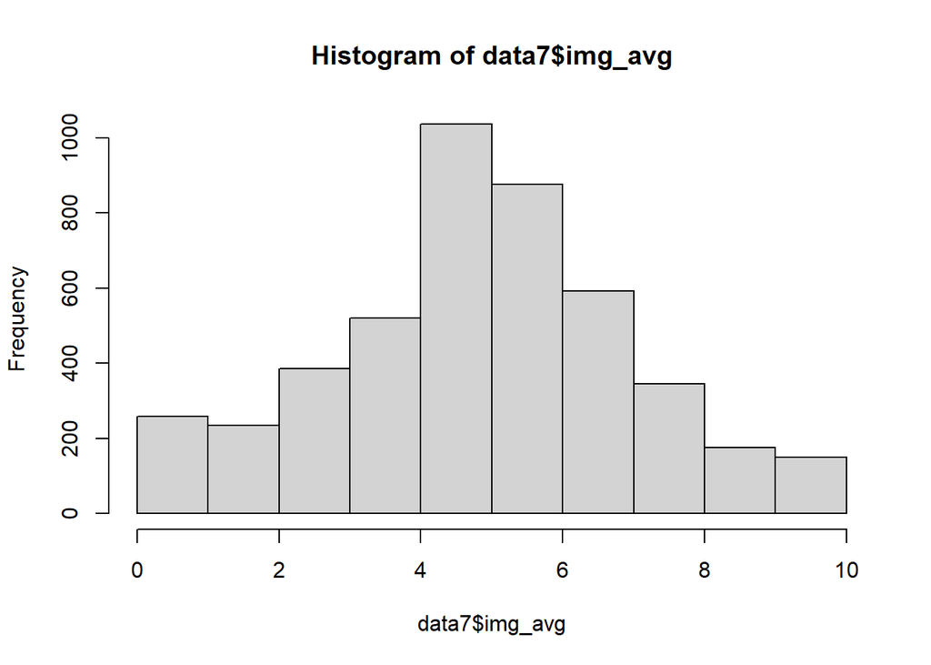

```r
hist(data7$img_avg)
```

```r
summary(data7)
```

```
##     cntry                agea            gndr          img_avg
##  Length:4574        Min.   :15.00   Min.   :1.000   Min.   : 0.000
##  Class :character   1st Qu.:39.00   1st Qu.:1.000   1st Qu.: 3.667
##  Mode  :character   Median :56.00   Median :2.000   Median : 5.000
##                     Mean   :53.77   Mean   :1.633   Mean   : 5.019
##                     3rd Qu.:68.00   3rd Qu.:2.000   3rd Qu.: 6.333
##                     Max.   :90.00   Max.   :2.000   Max.   :10.000
##     polintr         stflife
##  Min.   :1.000   Min.   : 0.000
##  1st Qu.:2.000   1st Qu.: 5.000
##  Median :3.000   Median : 7.000
##  Mean   :2.763   Mean   : 6.629
##  3rd Qu.:3.000   3rd Qu.: 8.000
##  Max.   :4.000   Max.   :10.000
```

```r
library(summarytools)
with(data7,
stby(data=data7$img_avg,
INDICES=data7$cntry,
FUN=descr,
stats=c("mean","sd","min","med","max","skewness")))
```

```
## Descriptive Statistics
## img_avg by cntry
## Data Frame: data7
## N: 1897
##
##                     EE      LT      LV
## -------------- ------- ------- -------
##           Mean    4.81    5.06    5.39
##        Std.Dev    2.04    2.19    2.33
##            Min    0.00    0.00    0.00
##         Median    5.00    5.00    5.33
##            Max   10.00   10.00   10.00
##       Skewness   -0.25   -0.12   -0.22
```

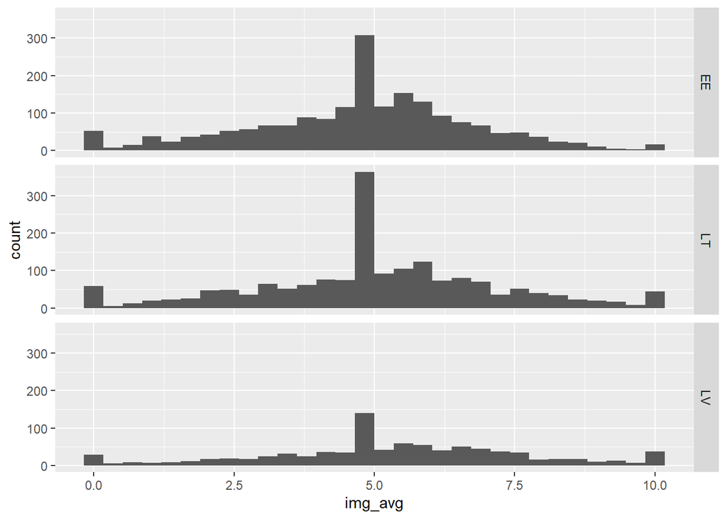

```r
# histograms by groups for img_avg
ggplot(data7, aes(x = img_avg)) +
  geom_histogram() + facet_grid(cntry ~ .)
```

Visually I can see that the histogram has a tail that goes to left. I will test if the data normally distributed.

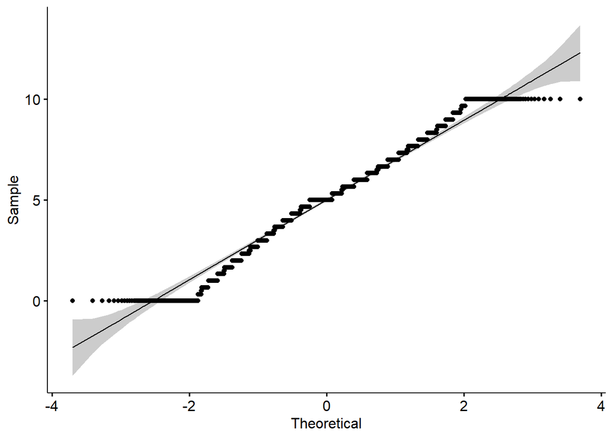

```r
#testing for normal distribution
library(ggpubr)
ggqqplot(data7$img_avg)
```

Dots are not following like entirely, going out of confidence intervals on both ends.

```r
#testing for normal distribution
library(dplyr)
library(rstatix)
data7 %>% group_by(cntry) %>% shapiro_test(img_avg)
```

| cntry | variable | statistic | p |
| --- | --- | --- | --- |
| EE | img_avg | 0.9849925 | 3.299749e-13 |
| LT | img_avg | 0.9827164 | 7.662170e-14 |
| LV | img_avg | 0.9806500 | 1.627366e-09 |

```r
# Statistical test of normality
# H0: variable is normally distributed, H1: variable is not normally distributed
shapiro.test(data7$img_avg)
```

```
##
##  Shapiro-Wilk normality test
##
## data:  data7$img_avg
## W = 0.98488, p-value < 2.2e-16
```

```r
ks.test(x = data7$img_avg, y = pnorm)
```

```
##
##  One-sample Kolmogorov-Smirnov test
##
## data:  data7$img_avg
## D = 0.89242, p-value < 2.2e-16
## alternative hypothesis: two-sided
```

As the p-value is smaller than 0.05, I reject the normality hypothesis. Therefore, I need to use the nonparametric version, the kruskal.test function: https://rc2e.com/linearregressionandanova#recipe-id231.

```r
# H0: The mean is the same for all groups
# H1: At least the mean of one group is different
kruskal.test(data7$img_avg ~ data7$cntry)
```

```
##
##  Kruskal-Wallis rank sum test
##
## data:  data7$img_avg by data7$cntry
## Kruskal-Wallis chi-squared = 43.226, df = 2, p-value = 4.107e-10
```